# PM 616 - Assignment 1

#### Sex vs. Survived

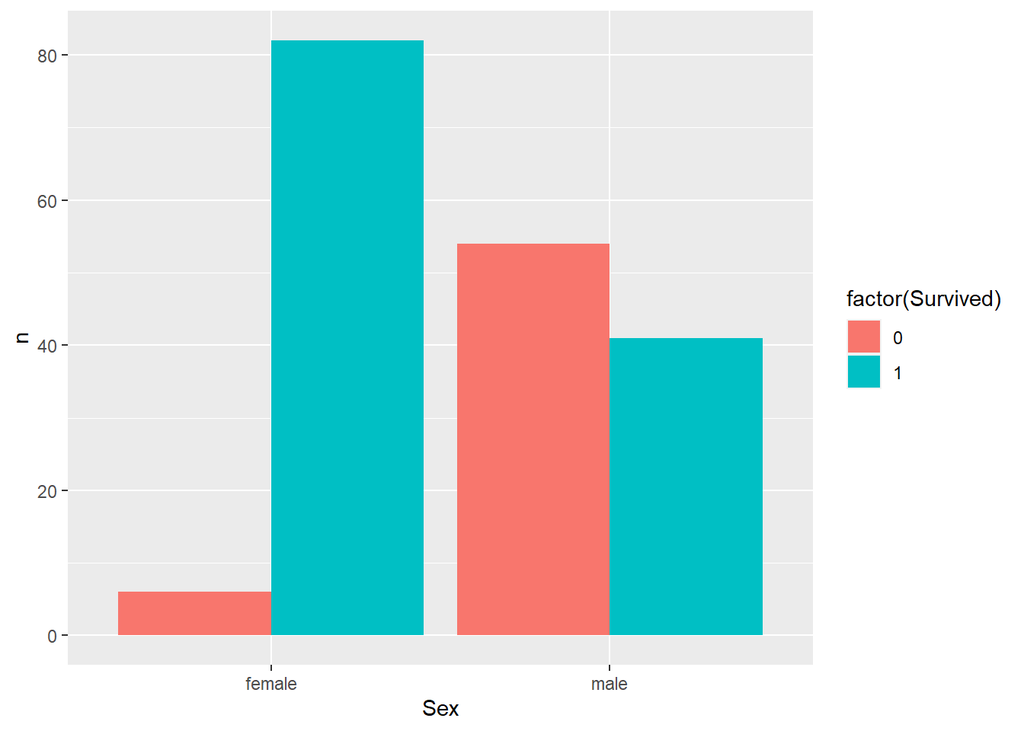

```r
train3 <-
  train %>%
  group_by(Sex, Survived) %>%
  tally()

train3 <-
  drop_na(train3)

ggplot(train3, aes(x = Sex, y = n, fill = factor(Survived))) +
  geom_bar(stat = 'identity', position = 'dodge')
```

#### Age vs. Survived

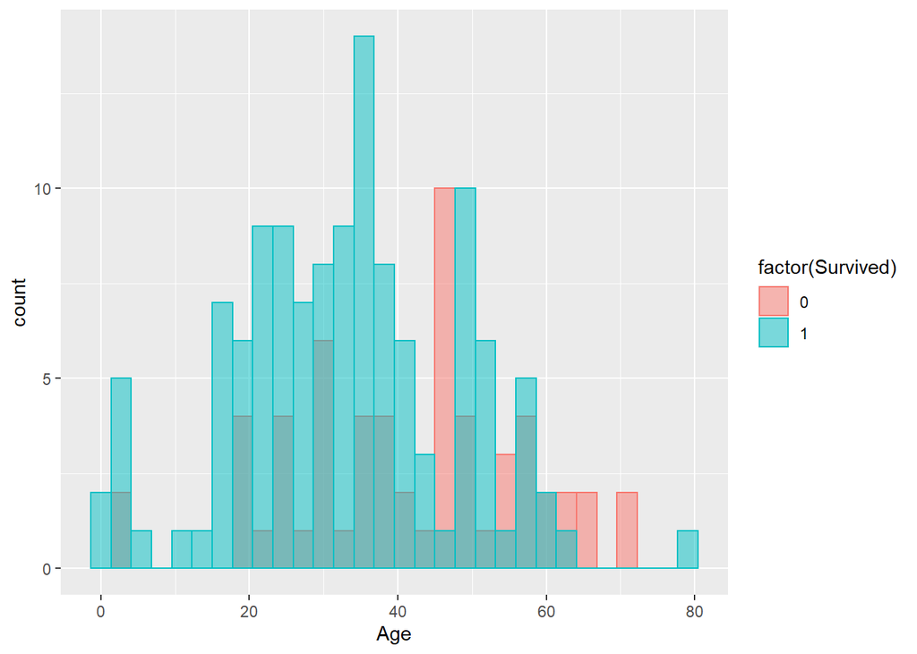

```r
ggplot(train, aes(x = Age, fill = factor(Survived), colour = factor(Survived))) +
  geom_histogram(alpha = 0.5, position = "identity")
```

#### Fare vs Survived

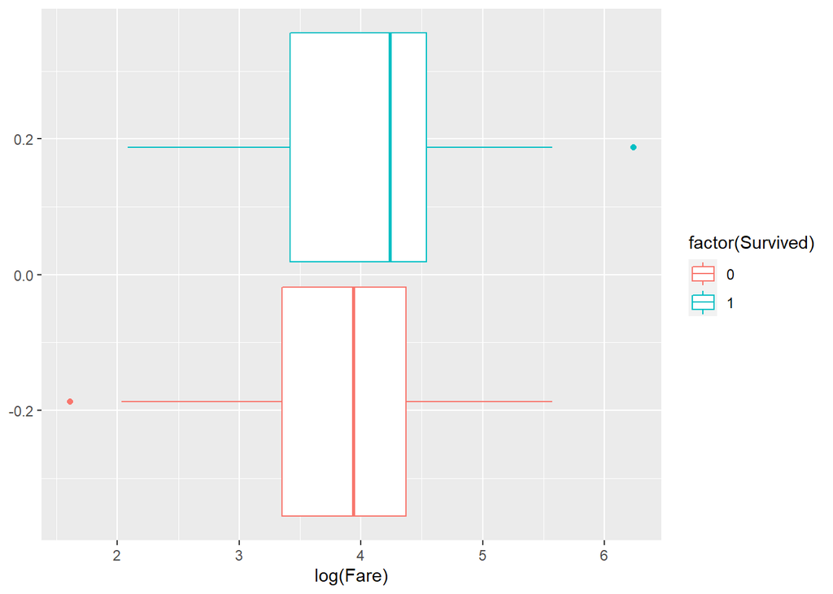

```r
ggplot(data = train, aes(log(Fare), color = factor(Survived))) +
  geom_boxplot()
```

#### Data Cleanup

```r
# sex
train$Sex <- ifelse(train$Sex == 'male', 1, 0)

# Embarked
train$Embarked_C <- ifelse(train$Embarked == 'C', 1, 0)
train$Embarked_Q <- ifelse(train$Embarked == 'Q', 1, 0)
train$Embarked_S <- ifelse(train$Embarked == 'S', 1, 0)

# remove variables
train <-
  train %>%
  select(-c(PassengerId, Name, Ticket, Cabin, Embarked))
```

#### Define Data/Labels

```r
# x train
x_train <- train %>% select(-c(Survived))
x_train <- as.matrix(x_train)
dimnames(x_train) = NULL
# y train
y_train <- as.matrix(train$Survived)
dimnames(y_train) = NULL

# x test
x_test <- as.matrix(test)
dimnames(x_test) = NULL
```

#### Model

```r
model <- keras_model_sequential() %>%
  layer_dense(units = 16, activation = "relu", input_shape = (9)) %>%
  layer_dense(units = 16, activation = "relu") %>%
  layer_dense(units = 1, activation = "sigmoid")
```

```
## Loaded Tensorflow version 2.9.2
```

#### Compile the Model

```r
model %>%
  compile(
  optimizer = "adam",
  loss = "binary_crossentropy",
  metrics = c("accuracy")
)
```

#### Fit Model

```r
history <-
  model %>%
  fit(x_train,
      y_train,
      epoch = 200,
      batch_size = 32,
      validation_split = 0.1,
      verbose = 2)
```

#### Plot History

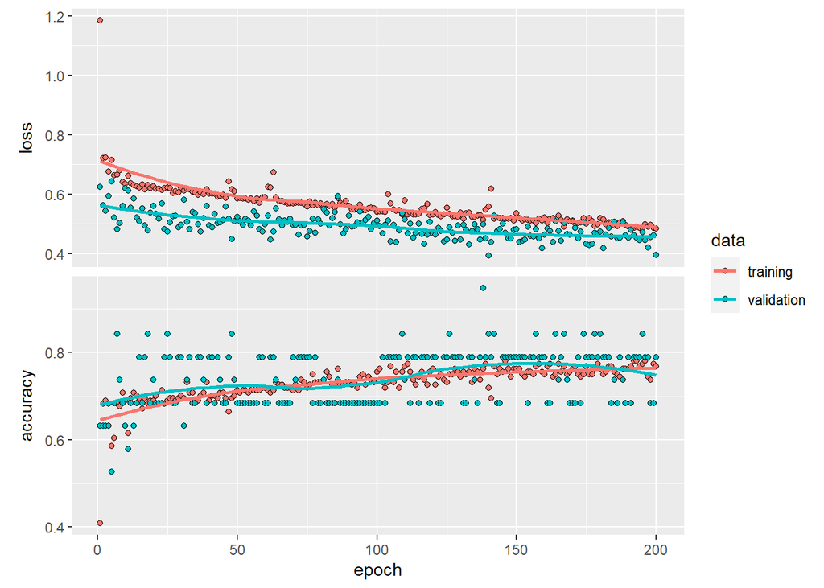

```r
plot(history)
```

#### Evaluate

```r
model %>%
  evaluate(x_train,
           y_train)
```

```
##      loss  accuracy
## 0.4877721 0.7322404
```

2. There are many analysis demonstrations of this dataset online, both in R and Python. Do not look at them. Try to get as much as possible yourself. Then look at other people’s solutions online (by just googling). Summarize what you have learned from them, and if you did something better than most of online demonstrations, briefly highlight them.

I learned that a lot of individuals pay close attention to missing parameters. There are methods of imputation and machine learning algorithms to predict missing values. A lot of time also seems spent on the feature engineering aspect. There was a notebook that used NLP techniques to extract meaningful data from the passenger’s name.